# Sleep Quality for Single Males

## 0.1 Preliminaries

```r
library(knitr)
library(rmdformats)
library(arm)
library(leaps)
library(tableone)
library(pander)
library(ROCR)
library(skimr)
library(rms)
library(broom)
library(dplyr)
library(tidyverse)
data(NHANES)
```

# 1 Task 1: Data Source

The data used in this study are from the survey data collected by the US National Center for Health Statistics. NHANES is unique in collecting person-level demographic, health, and nutrition information from personal interviews (interview) and a standardized physical examination in a mobile examination center (MEC). The examination includes objective measures of health status, including height, weight, blood pressure, and the collection of blood and urine specimens for laboratory testing.

Because of the oversampling issue in original data, this `NHANES` data contains 10,000 rows of data re-sampled from original data to reduce the oversampling issue.

# 2 Task 2: Load and Tidy the Data

## 2.1 Data Load

```r
nhanes<- NHANES::NHANES
```

As originally loaded, the `nhanes` data contain 10000 rows and 76 columns. We selected out the variables that are most correlated with our outcome about sleep. Since we want to know the sleep quality about subjects who are male and never married, the final data set includes 745 subjects with 12 related variables.

## 2.2 Select Related Variables

```r
nhanes1<- nhanes%>%
  filter(MaritalStatus == "NeverMarried" & Gender== "male")%>%
  select(ID, Age, BMI,LittleInterest, Depressed,SleepHrsNight,SleepTrouble, PhysActiveDays, AlcoholDay, HealthGen, Pulse, Smoke100)%>%
  mutate(HealthGen = fct_recode(HealthGen,
                                Good="Excellent",
                                Good ="Vgood",
                                Good ="Good",
                                Fair = "Fair",
                                Fair = "Poor"))
```

For convinence, we merge five levels in variable `HealthGen` into two difference levels `Good` and `Fair`.

```r
names(nhanes1)
```

```
 [1] "ID"             "Age"            "BMI"            "LittleInterest"
 [5] "Depressed"      "SleepHrsNight"  "SleepTrouble"   "PhysActiveDays"
 [9] "AlcoholDay"     "HealthGen"      "Pulse"          "Smoke100"
```

```r
write.csv(nhanes1,"PQHS432_project1_andrewShan_project1.csv")
```

## 2.3 Are there missing values?

```r
na.pattern(nhanes1)
```

```
pattern
000000000000 000000000010 000000001000 000000010000 000000010010
         292            9           53          255            1
000000011000 000001000000 000110000000 000110001000 000110001100
          63            1            1            1           27
000110001110 000110010000 000110011000 000110011100 000110011110
           3            2            1           22            8
001000010000 001000011000 001110001000
           4            1            1
```

In our new data set `nhanes1`, there are 292 cases with completed variables.

## 2.4 Missingness Summary by Variable

```r
glimpse(nhanes1)
```

```
Observations: 745
Variables: 12
$ ID             <int> 51667, 51748, 51776, 51799, 51801, 51933, 52017...
$ Age            <int> 50, 56, 30, 50, 26, 54, 31, 31, 20, 20, 20, 38,...
$ BMI            <dbl> 26.60, 24.98, 28.60, 29.83, 22.81, 35.82, 35.24...
$ LittleInterest <fct> None, None, None, None, None, None, None, None,...
$ Depressed      <fct> None, Several, None, None, None, None, None, No...
$ SleepHrsNight  <int> 7, 8, 6, 7, 7, 7, 7, 7, 9, 9, 7, 7, 7, 9, 7, 7,...
$ SleepTrouble   <fct> No, No, No, No, No, No, No, No, No, No, No, No,...
$ PhysActiveDays <int> 7, NA, NA, 3, 2, 1, 2, 2, 1, 1, NA, 5, NA, NA, ...
$ AlcoholDay     <int> NA, NA, 1, 4, 1, NA, 2, 2, NA, NA, NA, NA, 20, ...
$ HealthGen      <fct> Good, Fair, Good, Fair, Good, Good, Good, Good,...
$ Pulse          <int> 74, 66, 50, 72, 74, 72, 86, 86, 74, 74, 92, 66,...
$ Smoke100       <fct> No, No, Yes, No, No, Yes, No, No, No, No, No, Y...
```

```r
colSums(is.na(nhanes1))
```

```
            ID            Age            BMI LittleInterest      Depressed
             0              0              6             66             66
 SleepHrsNight   SleepTrouble PhysActiveDays     AlcoholDay      HealthGen
             1              0            357            180             60
         Pulse       Smoke100
            21              0
```

# 3 Task 3: Listing of My Tibble

```r
skim_with(numeric = list(hist = NULL), integer = list(hist = NULL))
skim(nhanes1)
```

```
Skim summary statistics
 n obs: 745
 n variables: 12

Variable type: factor
       variable missing complete   n n_unique
      Depressed      66      679 745        3
      HealthGen      60      685 745        2
 LittleInterest      66      679 745        3
   SleepTrouble       0      745 745        2
       Smoke100       0      745 745        2
                          top_counts ordered
 Non: 519, Sev: 107, NA: 66, Mos: 53   FALSE
           Goo: 587, Fai: 98, NA: 60   FALSE
 Non: 482, Sev: 146, NA: 66, Mos: 51   FALSE
            No: 586, Yes: 159, NA: 0   FALSE
            No: 386, Yes: 359, NA: 0   FALSE

Variable type: integer
       variable missing complete   n     mean      sd    p0   p25 median
            Age       0      745 745    33.36   13.54    20    23     28
     AlcoholDay     180      565 745     4.62    4.69     1     2      4
             ID       0      745 745 62741.67 5740.17 51667 57963  63230
 PhysActiveDays     357      388 745     3.34    1.83     1     2      3
          Pulse      21      724 745    72.28   11.93    40    64     70
  SleepHrsNight       1      744 745     6.83    1.29     3     6      7
   p75  p100
    41    80
     6    82
 67761 71915
     5     7
    80   106
     8    11

Variable type: numeric
 variable missing complete   n  mean   sd    p0  p25 median  p75 p100
      BMI       6      739 745 27.78 6.22 16.73 23.2   26.6 31.5 63.3
```

# 4 Task 4: Code Book

[output not shown]

# 5 Task 5: My Subjects

The data describe 745 male subjects who never married from survey done by the US National Center for Health Statistics.

# 6 Task 6: My Variables

1. **Gender**  
   Gender (sex) of study participant coded as male or female
2. **Age**  
   Age in years at screening of study participant. Note: Subjects 80 years or older were recorded as 80.
3. **BMI**  
   Body mass index (weight/height2 in kg/m2). Reported for participants aged 2 years or older.
4. **LittleInterest**  
   Self-reported number of days where participant had little interest in doing things. Reported for participants aged 18 years or older. One of None, Several, Majority (more than half the days), or AlmostAll.
5. **Depressed**  
   Self-reported number of days where participant felt down, depressed or hopeless. Reported for participants aged 18 years or older. One of None, Several, Majority (more than half the days), or AlmostAll.
6. **SleepHrsNight**  
   Self-reported number of hours study participant usually gets at night on weekdays or workdays. Reported for participants aged 16 years and older.
7. **SleepTrouble**  
   Participant has told a doctor or other health professional that they had trouble sleeping. Reported for participants aged 16 years and older. Coded as Yes or No.
8. **PhysActiveDays**  
   Number of days in a typical week that participant does moderate or vigorous-intensity activity. Reported for participants 12 years or older.
9. **AlcoholDay**  
   Average number of drinks consumed on days that participant drank alcoholic beverages. Reported for participants aged 18 years or older.
10. **HealthGen**  
    Self-reported rating of participant’s health in general Reported for participants aged 12 years or older. One of Good, Fair.
11. **Pulse**  
    60 second pulse rate
12. **Smoke100**  
    Study participant has smoked at least 100 cigarettes in their entire life. Reported for participants aged 20 years or older as Yes or No.

# 7 Task 7: My Planned Linear Regression Model

In my linear regression model, the outcome will be `SleepHrsNight` and predictors will include `Age`, `PhyActiveDays`, `AlcoholDay`, and `Depressed`, which is a multi-categorical variable.

## 7.1 Spearman $rho$ Plot

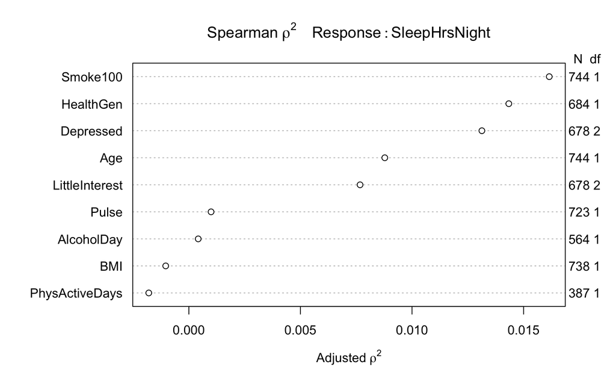

```r
plot(spearman2(SleepHrsNight~Age
               +BMI+LittleInterest+Depressed+PhysActiveDays+AlcoholDay
               +HealthGen+Pulse+Smoke100, data = nhanes1))
```

# 8 Task 8: My Planned Logistic Regression Model

In my logistic regression model, the outcome will be `SleepTrouble` and predictors will be `BMI`, `Age`, `Pulse`, `Smoke100`, and `LittleInterest`, which is a multi-categorical variable.

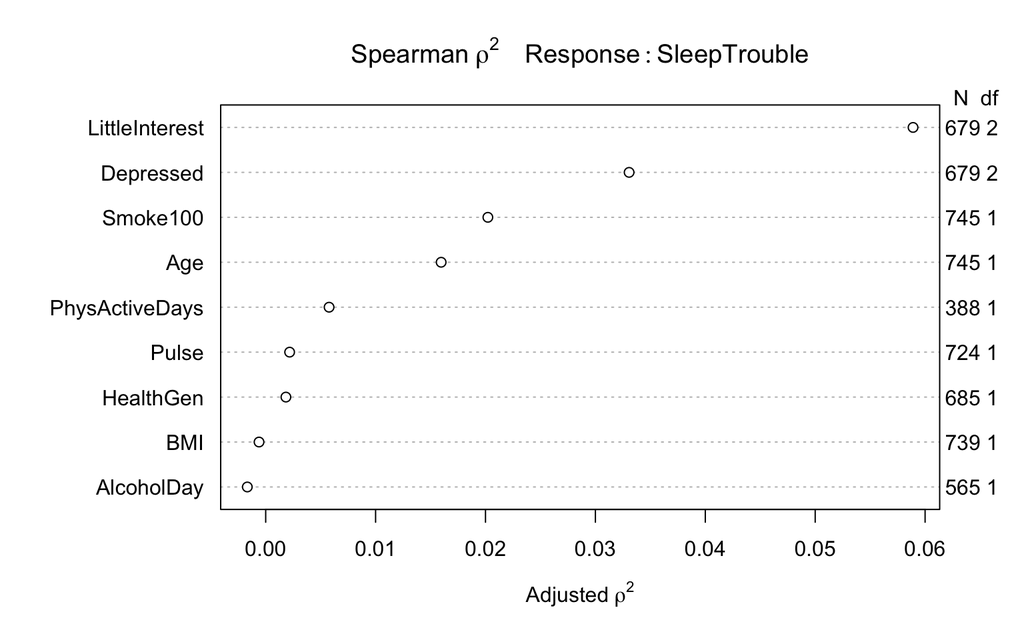

```r
plot(spearman2(SleepTrouble~Age
               +BMI+LittleInterest+Depressed+PhysActiveDays+AlcoholDay
               +HealthGen+Pulse+Smoke100, data = nhanes1))
```

# 9 Task 9: Affirmation

# 10 An Analysis: Linear Regression

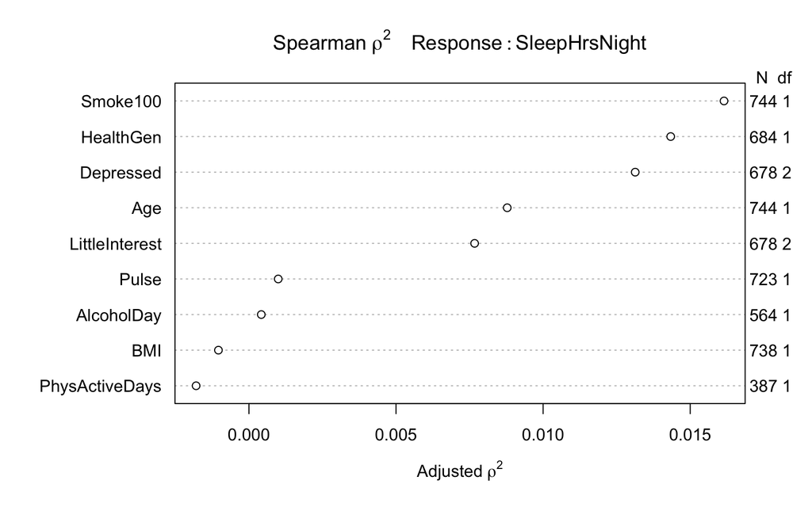

```r
plot(spearman2(SleepHrsNight~Age
               +BMI+LittleInterest+Depressed+PhysActiveDays+AlcoholDay
               +HealthGen+Pulse+Smoke100, data = nhanes1))
```

## 10.1 Model A. Modified Kitchen Sink

Based on the Spearman #pho#, we select a model with all of our candidate predictors, including an interactive between `age` and `Smoke100`, ignoring the missing values for a while.

```r
d <- datadist(nhanes1)
options(datadist = "d")
model1 <- ols(SleepHrsNight~Age*Smoke100+HealthGen
               +BMI+LittleInterest+Depressed+PhysActiveDays+AlcoholDay
               +Pulse, data = nhanes1,x=T, y=T)
model1
```

```
Frequencies of Missing Values Due to Each Variable
 SleepHrsNight            Age       Smoke100      HealthGen            BMI
             1              0              0             60              6
LittleInterest      Depressed PhysActiveDays     AlcoholDay          Pulse
            66             66            357            180             21

Linear Regression Model

 ols(formula = SleepHrsNight ~ Age * Smoke100 + HealthGen + BMI +
     LittleInterest + Depressed + PhysActiveDays + AlcoholDay +
     Pulse, data = nhanes1, x = T, y = T)


                Model Likelihood     Discrimination
                   Ratio Test           Indexes
 Obs     292    LR chi2     34.17    R2       0.110
 sigma1.1824    d.f.           12    R2 adj   0.072
 d.f.    279    Pr(> chi2) 0.0006    g        0.460

 Residuals

      Min       1Q   Median       3Q      Max
 -3.65912 -0.79322 -0.01284  0.73937  4.07007


                        Coef    S.E.   t     Pr(>|t|)
 Intercept               6.7623 0.6421 10.53 <0.0001
 Age                    -0.0072 0.0109 -0.66 0.5125
 Smoke100=Yes           -0.1979 0.4188 -0.47 0.6368
 HealthGen=Fair         -0.4731 0.2244 -2.11 0.0359
 BMI                    -0.0168 0.0118 -1.42 0.1556
 LittleInterest=Several  0.4659 0.1758  2.65 0.0085
 LittleInterest=Most    -0.0169 0.4038 -0.04 0.9666
 Depressed=Several      -0.1995 0.2215 -0.90 0.3687
 Depressed=Most         -0.4796 0.4207 -1.14 0.2552
 PhysActiveDays          0.0269 0.0403  0.67 0.5045
 AlcoholDay             -0.0475 0.0237 -2.01 0.0458
 Pulse                   0.0129 0.0064  2.01 0.0450
 Age * Smoke100=Yes      0.0013 0.0133  0.10 0.9218
```

### 10.1.1 ANOVA plot

```r
anova(model1)
```

```
                Analysis of Variance          Response: SleepHrsNight

 Factor                                        d.f. Partial SS
 Age  (Factor+Higher Order Factors)              2    1.34774714
  All Interactions                               1    0.01349076
 Smoke100  (Factor+Higher Order Factors)         2    1.60921420
  All Interactions                               1    0.01349076
 HealthGen                                       1    6.21663025
 BMI                                             1    2.83476956
 LittleInterest                                  2   10.61525109
 Depressed                                       2    2.41129909
 PhysActiveDays                                  1    0.62437649
 AlcoholDay                                      1    5.62466541
 Pulse                                           1    5.66871329
 Age * Smoke100  (Factor+Higher Order Factors)   1    0.01349076
 REGRESSION                                     12   48.42547956
 ERROR                                         279  390.05397249
 MS         F    P
 0.67387357 0.48 0.6181
 0.01349076 0.01 0.9218
 0.80460710 0.58 0.5631
 0.01349076 0.01 0.9218
 6.21663025 4.45 0.0359
 2.83476956 2.03 0.1556
 5.30762555 3.80 0.0236
 1.20564954 0.86 0.4233
 0.62437649 0.45 0.5045
 5.62466541 4.02 0.0458
 5.66871329 4.05 0.0450
 0.01349076 0.01 0.9218
 4.03545663 2.89 0.0009
 1.39804291
```

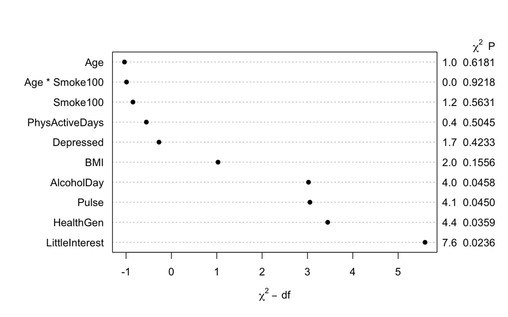

```r
plot(anova(model1))
```

According to ANOVA, four of these precdictors inclduing `AlcoholDay`, `Pulse`, `HealthGen`, and `Littleinterest` show statistically significant, but the interaction term does not show statistically sognificance.

## 10.2 Model A (with imputation)

### 10.2.1 Imputation Model

I’ll build the imputation model using my outcome, and the variables with at least one missing value, in this case.

```r
model1.A <- aregImpute(~ SleepHrsNight+HealthGen
               +BMI+LittleInterest+Depressed+PhysActiveDays+AlcoholDay
               +Pulse,
                  data = nhanes1,
                  n.impute = 100,
                  pr = FALSE, x = TRUE)
model1.A
```

```
Multiple Imputation using Bootstrap and PMM

aregImpute(formula = ~SleepHrsNight + HealthGen + BMI + LittleInterest +
    Depressed + PhysActiveDays + AlcoholDay + Pulse, data = nhanes1,
    n.impute = 100, x = TRUE, pr = FALSE)

n: 745  p: 8    Imputations: 100    nk: 3

Number of NAs:
 SleepHrsNight      HealthGen            BMI LittleInterest      Depressed
             1             60              6             66             66
PhysActiveDays     AlcoholDay          Pulse
           357            180             21

               type d.f.
SleepHrsNight     s    2
HealthGen         c    1
BMI               s    2
LittleInterest    c    2
Depressed         c    2
PhysActiveDays    s    2
AlcoholDay        s    2
Pulse             s    1

Transformation of Target Variables Forced to be Linear

R-squares for Predicting Non-Missing Values for Each Variable
Using Last Imputations of Predictors
 SleepHrsNight      HealthGen            BMI LittleInterest      Depressed
         0.122          0.146          0.100          0.440          0.481
PhysActiveDays     AlcoholDay          Pulse
         0.134          0.159          0.092
```

### 10.2.2 Fitting the Model after Imputation

```r
fmi.model1.a <- fit.mult.impute(SleepHrsNight~Age*Smoke100+HealthGen
               +BMI+LittleInterest+Depressed+PhysActiveDays+AlcoholDay
               +Pulse,
                           ols, model1.A, data = nhanes1)
```

```
Variance Inflation Factors Due to Imputation:

             Intercept                    Age           Smoke100=Yes
                  1.12                   1.01                   1.01
        HealthGen=Fair                    BMI LittleInterest=Several
                  1.10                   1.05                   1.12
   LittleInterest=Most      Depressed=Several         Depressed=Most
                  1.13                   1.13                   1.13
        PhysActiveDays             AlcoholDay                  Pulse
                  1.88                   1.49                   1.07
    Age * Smoke100=Yes
                  1.01

Rate of Missing Information:

             Intercept                    Age           Smoke100=Yes
                  0.10                   0.01                   0.01
        HealthGen=Fair                    BMI LittleInterest=Several
                  0.09                   0.05                   0.10
   LittleInterest=Most      Depressed=Several         Depressed=Most
                  0.11                   0.11                   0.12
        PhysActiveDays             AlcoholDay                  Pulse
                  0.47                   0.33                   0.06
    Age * Smoke100=Yes
                  0.01

d.f. for t-distribution for Tests of Single Coefficients:

             Intercept                    Age           Smoke100=Yes
               9191.40              476783.82             1178306.97
        HealthGen=Fair                    BMI LittleInterest=Several
              11347.37               38751.98                9121.12
   LittleInterest=Most      Depressed=Several         Depressed=Most
               7596.97                7563.06                7380.80
        PhysActiveDays             AlcoholDay                  Pulse
                454.03                 903.50               24181.16
    Age * Smoke100=Yes
            1185410.96

The following fit components were averaged over the 100 model fits:

  fitted.values stats linear.predictors
```

```r
fmi.model1.a
```

```
Linear Regression Model

 fit.mult.impute(formula = SleepHrsNight ~ Age * Smoke100 + HealthGen +
     BMI + LittleInterest + Depressed + PhysActiveDays + AlcoholDay +
     Pulse, fitter = ols, xtrans = model1.A, data = nhanes1)

                Model Likelihood     Discrimination
                   Ratio Test           Indexes
 Obs     745    LR chi2     53.73    R2       0.070
 sigma1.2578    d.f.           12    R2 adj   0.054
 d.f.    732    Pr(> chi2) 0.0000    g        0.368

 Residuals

      Min       1Q   Median       3Q      Max
 -4.33751 -0.89987 -0.03137  0.88423  4.37603


                        Coef    S.E.   t     Pr(>|t|)
 Intercept               6.5889 0.4128 15.96 <0.0001
 Age                     0.0004 0.0056  0.08 0.9373
 Smoke100=Yes           -0.0215 0.2560 -0.08 0.9331
 HealthGen=Fair         -0.4566 0.1449 -3.15 0.0017
 BMI                    -0.0059 0.0080 -0.73 0.4662
 LittleInterest=Several  0.2008 0.1315  1.53 0.1271
 LittleInterest=Most    -0.0724 0.2543 -0.28 0.7761
 Depressed=Several      -0.0950 0.1521 -0.62 0.5324
 Depressed=Most         -0.5329 0.2505 -2.13 0.0337
 PhysActiveDays          0.0241 0.0354  0.68 0.4963
 AlcoholDay             -0.0211 0.0123 -1.71 0.0882
 Pulse                   0.0086 0.0042  2.05 0.0403
 Age * Smoke100=Yes     -0.0068 0.0072 -0.95 0.3436
```

### 10.2.3 ANOVA plot after imputation

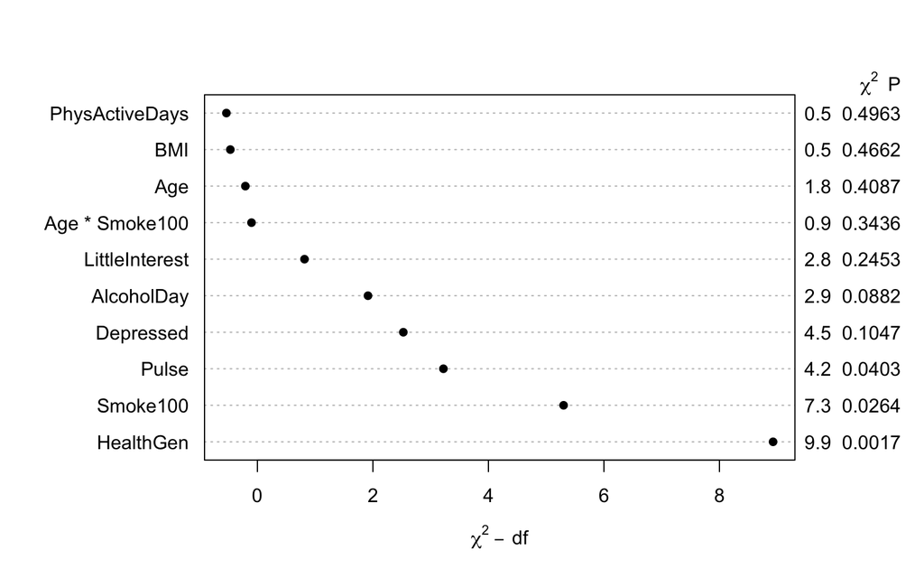

```r
plot(anova(fmi.model1.a))
```

### 10.2.4 Effects plot after imputation

```r
summary(fmi.model1.a)
```

```
             Effects              Response : SleepHrsNight

 Factor                        Low  High Diff. Effect     S.E.
 Age                           23.0 41.0 18.0   0.0080073 0.101680
 BMI                           23.2 31.5  8.3  -0.0486380 0.066720
 PhysActiveDays                 2.0  5.0  3.0   0.0722810 0.106200
 AlcoholDay                     2.0  6.0  4.0  -0.0843200 0.049389
 Pulse                         64.0 80.0 16.0   0.1382800 0.067307
 Smoke100 - Yes:No              1.0  2.0   NA  -0.2120800 0.103560
 HealthGen - Fair:Good          1.0  2.0   NA  -0.4565900 0.144910
 LittleInterest - Several:None  1.0  2.0   NA   0.2007900 0.131480
 LittleInterest - Most:None     1.0  3.0   NA  -0.0723570 0.254300
 Depressed - Several:None       1.0  2.0   NA  -0.0949820 0.152070
 Depressed - Most:None          1.0  3.0   NA  -0.5328900 0.250470
 Lower 0.95 Upper 0.95
 -0.1916000  0.207620
 -0.1796200  0.082347
 -0.1362200  0.280780
 -0.1812800  0.012642
  0.0061406  0.270420
 -0.4154000 -0.008768
 -0.7410700 -0.172110
 -0.0573270  0.458910
 -0.5716000  0.426890
 -0.3935300  0.203560
 -1.0246000 -0.041164

Adjusted to: Age=28 Smoke100=No
```

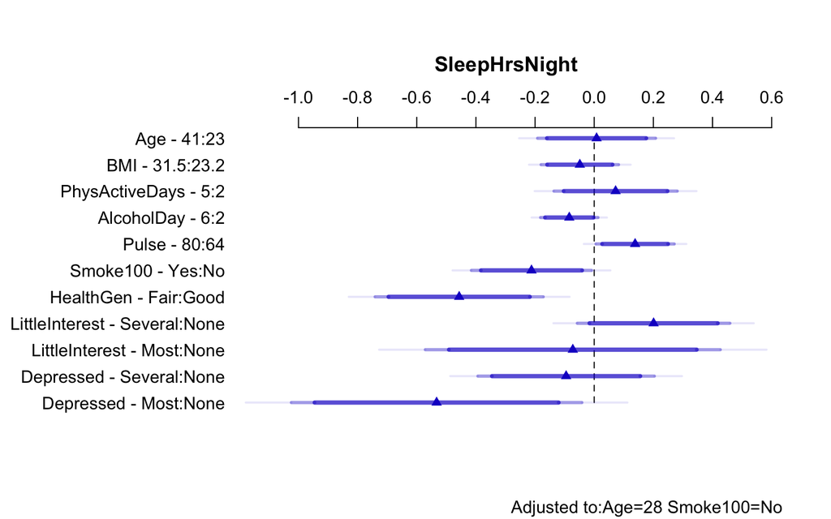

```r
plot(summary(fmi.model1.a))
```

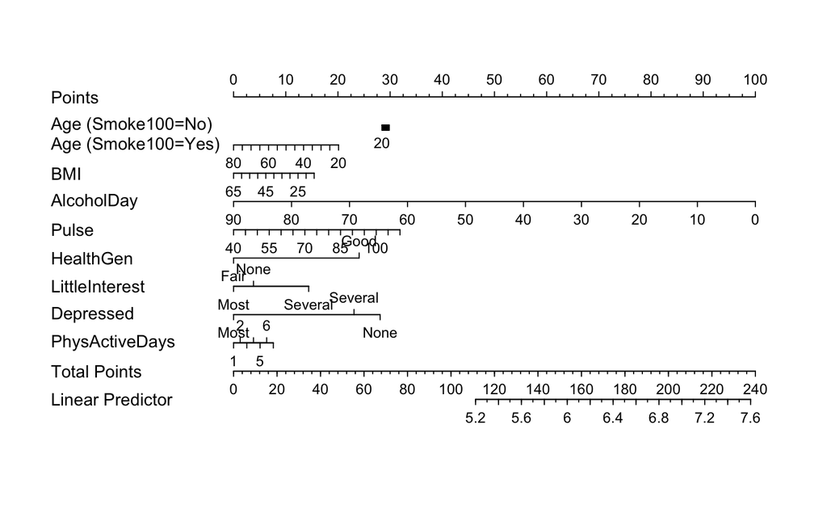

```r
plot(nomogram(fmi.model1.a))
```

## 10.3 Running “Best Subsets” to select predictors

Mostly for completeness, next we’ll consider models with main effects only, again just excluding the observations with missing values, and run our “best subsets” comparisons to consider potential models.

```r
preds <- with(na.omit(nhanes1), cbind(Age,Smoke100,HealthGen,BMI,LittleInterest,Depressed,PhysActiveDays,AlcoholDay,Pulse))
x1 <- regsubsets(preds, na.omit(nhanes1)$SleepHrsNight, nvmax=9)
rs.sum <- summary(x1)
rs.sum
```

```
Subset selection object
9 Variables  (and intercept)
               Forced in Forced out
Age                FALSE      FALSE
Smoke100           FALSE      FALSE
HealthGen          FALSE      FALSE
BMI                FALSE      FALSE
LittleInterest     FALSE      FALSE
Depressed          FALSE      FALSE
PhysActiveDays     FALSE      FALSE
AlcoholDay         FALSE      FALSE
Pulse              FALSE      FALSE
1 subsets of each size up to 9
Selection Algorithm: exhaustive
         Age Smoke100 HealthGen BMI LittleInterest Depressed
1  ( 1 ) " " " "      "*"       " " " "            " "
2  ( 1 ) " " "*"      "*"       " " " "            " "
3  ( 1 ) " " "*"      "*"       " " " "            " "
4  ( 1 ) " " " "      "*"       " " "*"            "*"
5  ( 1 ) " " " "      "*"       " " "*"            "*"
6  ( 1 ) " " " "      "*"       "*" "*"            "*"
7  ( 1 ) " " "*"      "*"       "*" "*"            "*"
8  ( 1 ) "*" "*"      "*"       "*" "*"            "*"
9  ( 1 ) "*" "*"      "*"       "*" "*"            "*"
         PhysActiveDays AlcoholDay Pulse
1  ( 1 ) " "            " "        " "
2  ( 1 ) " "            " "        " "
3  ( 1 ) " "            "*"        " "
4  ( 1 ) " "            "*"        " "
5  ( 1 ) " "            "*"        "*"
6  ( 1 ) " "            "*"        "*"
7  ( 1 ) " "            "*"        "*"
8  ( 1 ) " "            "*"        "*"
9  ( 1 ) "*"            "*"        "*"
```

```r
round(rs.sum$adjr2, 4)
```

```
[1] 0.0298 0.0406 0.0483 0.0563 0.0624 0.0655 0.0686 0.0676 0.0652
```

```r
round(rs.sum$cp, 1)
```

```
[1] 13.0 10.6  9.2  7.7  6.9  6.9  7.0  8.3 10.0
```

```r
round(rs.sum$bic, 1)
```

```
[1]  1.5  2.9  5.2  7.4 10.2 13.9 17.6 22.5 27.9
```

```r
rs.sum$aic.corr <- 292*log(rs.sum$rss / 292) + 2*(2:10) +
               (2 * (2:10) * ((2:10)+1) / (292 - (2:10) - 1))
round(rs.sum$aic.corr,1)
```

```
[1] 112.9 110.7 109.4 108.0 107.1 107.2 107.4 108.8 110.6
```

### 10.3.1 Building the Four Summary Plots

```r
best_mods_1 <- data_frame( k = 2:10,
                           r2 = rs.sum$rsq, adjr2 = rs.sum$adjr2, cp = rs.sum$cp, aic.c = rs.sum$aic.c, bic = rs.sum$bic)
rs.sum <- cbind(best_mods_1, rs.sum$which)
```

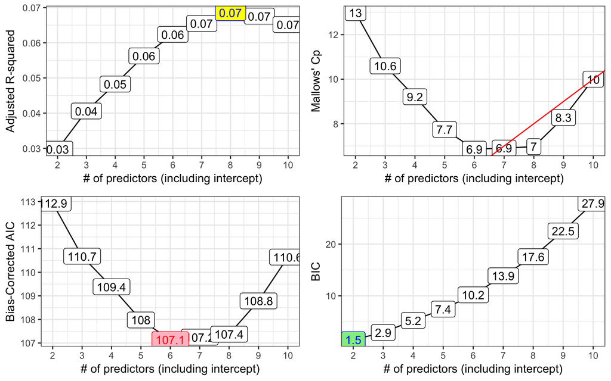

```r
p1<- ggplot(rs.sum, aes(x = k, y = adjr2,label = round(adjr2,2))) +
  geom_line() +
  geom_label() +
  geom_label(data = subset(rs.sum,adjr2 == max(adjr2)),aes(x = k, y = adjr2, label = round(adjr2,2)),
             fill = "yellow", col = "blue") + theme_bw() +
  scale_x_continuous(breaks = 2:10) +
  labs(x = "# of predictors (including intercept)",y = "Adjusted R-squared")

p2<- ggplot(rs.sum, aes(x = k, y = cp,
                   label = round(cp,1))) +
  geom_line() +geom_label() +geom_abline(intercept = 0, slope = 1,col = "red") + theme_bw() +
  scale_x_continuous(breaks = 2:10) +
  labs(x = "# of predictors (including intercept)",y = "Mallows' Cp")

p3<- ggplot(rs.sum, aes(x = k, y = aic.c,label = round(aic.c,1))) +geom_line() +
  geom_label() +geom_label(data = subset(rs.sum, aic.c == min(aic.c)),aes(x = k, y = aic.c), fill = "pink",
                           col = "red") + theme_bw() +
  scale_x_continuous(breaks = 2:10) +labs(x = "# of predictors (including intercept)",y = "Bias-Corrected AIC")

p4<- ggplot(rs.sum, aes(x = k, y = bic,label = round(bic,1))) +
  geom_line() +
  geom_label() +
  geom_label(data = subset(rs.sum, bic == min(bic)),aes(x = k, y = bic),fill = "lightgreen", col = "blue") + theme_bw() +
  scale_x_continuous(breaks = 2:10) +
  labs(x = "# of predictors (including intercept)",y = "BIC")
gridExtra::grid.arrange(p1, p2, p3, p4, nrow = 2)
```

### 10.3.2 Candidate Models from “Best Subsets”

The models we’ll consider are:

[output not shown]

### 10.3.3 Comparison of Candidate Models via ANOVA

```r
lm0 <- lm(SleepHrsNight ~ 1, data = na.omit(nhanes1))
lm1 <- lm(SleepHrsNight ~ HealthGen, data = na.omit(nhanes1))
lm5 <- lm(SleepHrsNight ~ HealthGen+LittleInterest+Depressed+AlcoholDay+Pulse,
           data = na.omit(nhanes1))
lm6<-lm(SleepHrsNight ~ HealthGen+LittleInterest+Depressed+AlcoholDay+Pulse+BMI,
           data = na.omit(nhanes1))
lm7 <- lm(SleepHrsNight ~  HealthGen+LittleInterest+Depressed+AlcoholDay+Pulse+BMI+Smoke100,
           data = na.omit(nhanes1))
```

```r
anova(lm7,lm6,lm5,lm1,lm0)
```

```
Analysis of Variance Table

Model 1: SleepHrsNight ~ HealthGen + LittleInterest + Depressed + AlcoholDay +
    Pulse + BMI + Smoke100
Model 2: SleepHrsNight ~ HealthGen + LittleInterest + Depressed + AlcoholDay +
    Pulse + BMI
Model 3: SleepHrsNight ~ HealthGen + LittleInterest + Depressed + AlcoholDay +
    Pulse
Model 4: SleepHrsNight ~ HealthGen
Model 5: SleepHrsNight ~ 1
  Res.Df    RSS Df Sum of Sq       F   Pr(>F)
1    282 392.07
2    283 394.79 -1   -2.7272  1.9616 0.162443
3    284 397.90 -1   -3.1063  2.2343 0.136099
4    290 423.97 -6  -26.0733  3.1256 0.005560 **
5    291 438.48 -1  -14.5072 10.4346 0.001383 **
---
Signif. codes:  0 '***' 0.001 '**' 0.01 '*' 0.05 '.' 0.1 ' ' 1
```

The ANOVA suggests the model with five predictors, and six inputs (including the intercept). Let’s run that as our model B.

## 10.4 Model B

```r
model2 <- ols(SleepHrsNight ~ HealthGen+LittleInterest+Depressed+AlcoholDay+Pulse,
           data = nhanes1, x= T, y= T)
model2
```

```
Frequencies of Missing Values Due to Each Variable
 SleepHrsNight      HealthGen LittleInterest      Depressed     AlcoholDay
             1             60             66             66            180
         Pulse
            21

Linear Regression Model

 ols(formula = SleepHrsNight ~ HealthGen + LittleInterest + Depressed +
     AlcoholDay + Pulse, data = nhanes1, x = T, y = T)


                Model Likelihood     Discrimination
                   Ratio Test           Indexes
 Obs     551    LR chi2     31.50    R2       0.056
 sigma1.2544    d.f.            7    R2 adj   0.043
 d.f.    543    Pr(> chi2) 0.0001    g        0.300

 Residuals

      Min       1Q   Median       3Q      Max
 -3.79195 -0.87984  0.05616  0.91654  4.24724


                        Coef    S.E.   t     Pr(>|t|)
 Intercept               6.5303 0.3345 19.52 <0.0001
 HealthGen=Fair         -0.5699 0.1605 -3.55 0.0004
 LittleInterest=Several  0.2530 0.1394  1.81 0.0702
 LittleInterest=Most     0.0848 0.3016  0.28 0.7788
 Depressed=Several      -0.1835 0.1699 -1.08 0.2806
 Depressed=Most         -0.8014 0.3217 -2.49 0.0130
 AlcoholDay             -0.0185 0.0114 -1.62 0.1057
 Pulse                   0.0060 0.0046  1.29 0.1965
```

### 10.4.1 ANOVA plot for Model B

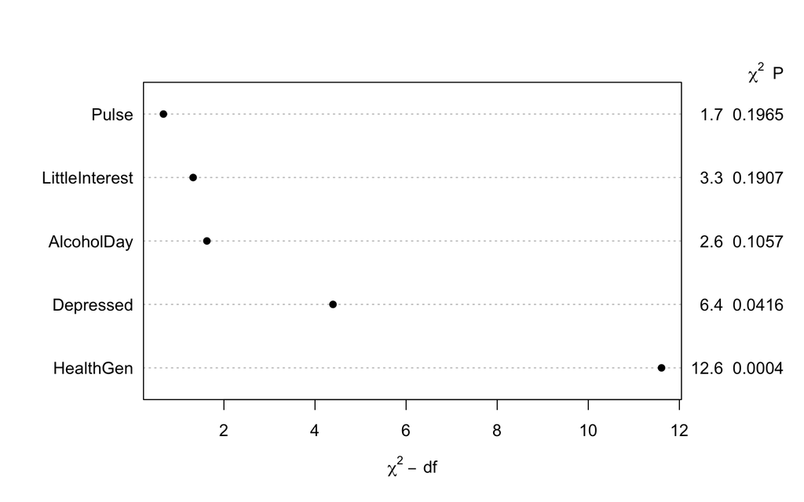

```r
plot(anova(model2))
```

### 10.4.2 Validation of Model B Summary Statistics

```r
set.seed(432); validate(model2)
```

```
          index.orig training   test optimism index.corrected  n
R-square      0.0556   0.0681 0.0371   0.0309          0.0246 40
MSE           1.5507   1.5067 1.5810  -0.0743          1.6251 40
g             0.2998   0.3204 0.2616   0.0588          0.2410 40
Intercept     0.0000   0.0000 1.0945  -1.0945          1.0945 40
Slope         1.0000   1.0000 0.8381   0.1619          0.8381 40
```

### 10.4.3 Nomogram of Model B

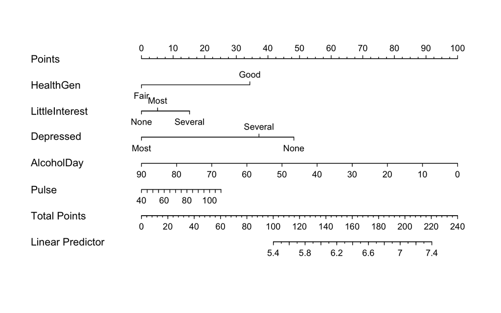

```r
plot(nomogram(model2))
```

```r
##Predict(model2, baseEF = seq(20, 80, 20), dose = c(10, 40))
```

### 10.4.5 Fitting Model B with lm

```r
model.2 <- lm(SleepHrsNight ~ HealthGen+LittleInterest+Depressed+AlcoholDay+Pulse,data = nhanes1)
display(model.2)
```

```
lm(formula = SleepHrsNight ~ HealthGen + LittleInterest + Depressed +
    AlcoholDay + Pulse, data = nhanes1)
                      coef.est coef.se
(Intercept)            6.53     0.33
HealthGenFair         -0.57     0.16
LittleInterestSeveral  0.25     0.14
LittleInterestMost     0.08     0.30
DepressedSeveral      -0.18     0.17
DepressedMost         -0.80     0.32
AlcoholDay            -0.02     0.01
Pulse                  0.01     0.00
---
n = 551, k = 8
residual sd = 1.25, R-Squared = 0.06
```

### 10.4.6 Residual Plots for Model B

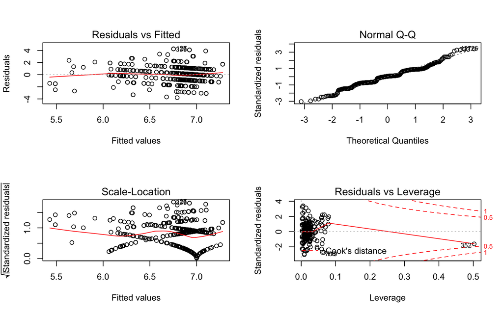

```r
par(mfrow=c(2,2))
plot(model.2)
```

# 11 An Analysis: Logistic Regression

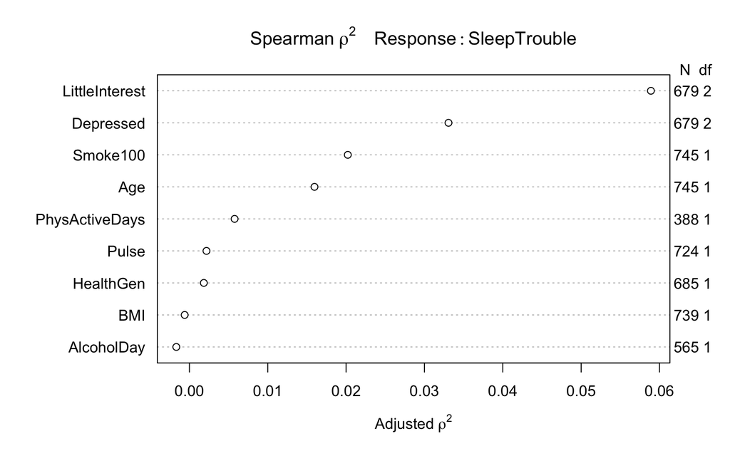

```r
plot(spearman2(SleepTrouble~Age
               +BMI+LittleInterest+Depressed+PhysActiveDays+AlcoholDay
               +HealthGen+Pulse+Smoke100, data = nhanes1))
```

Andrew Shan

2018-03-08 04:19:44